# A short guide to analysing visual projection neurons

## Set up environment

```r
# Allow production of figures using RGL
library(knitr)
knit_hooks$set(rgl = hook_rgl)
opts_chunk$set(dev = c("png", "pdf"))
# sidestep a bug in knitr that fails to produce output dir for rgl snapshots
dir.create("figure")
```

### Load flycircuit and nat packages

```r
library(flycircuit)
library(nat)
```

## Load VPN NBLAST scores

Download NBLAST scores for VPNs and load them into the workspace.

```r
# Download scores...
fc_download_data("http://jefferislab.org/si/nblast/flycircuit/vpnsblastcv2.5.ff",
    type = "ff")
```

```
## [1] TRUE
```

```r
# ...and set an option to use them as the default
options(flycircuit.scoremat = "vpnsblastcv2.5.ff")
```

Show the top 10 scores for the a neuron:

```r
scores = fc_nblast("ChaMARCM-F000003_seg001")
```

```
## attaching: vpnsblastcv2.5
## opening ff /Library/Frameworks/R.framework/Versions/3.0/Resources/library/flycircuit/extdata/ff/vpnsblastcv2.5.ff
```

```r
sort(scores, decreasing = TRUE)[1:10]
```

```
##    ChaMARCM-F000003_seg001    GadMARCM-F000623_seg002
##                       6253                       3607
##    ChaMARCM-F000289_seg001    FruMARCM-M000008_seg001
##                       3470                       3411
##    ChaMARCM-F000826_seg001 DvGlutMARCM-F002277_seg001
##                       3343                       3321
## DvGlutMARCM-F002956_seg001    ChaMARCM-F000087_seg002
##                       3302                       3251
## DvGlutMARCM-F004615_seg001 DvGlutMARCM-F004068_seg001
##                       3232                       3150
```

## Download VPN morphologies

At the moment we have the NBLAST scores for the VPNs, but no other information about them. Let's download the neurons. Or rather the neurons, but an object that we can save to our local disk that contains information about what neurons are present.

```r
# Download the data
vpns <- read.neuronlistfh("http://jefferislab.org/si/nblast/flycircuit/vpns.rds",
    getOption("flycircuit.datadir"))
# show what kind of data we have for the neurons
head(vpns)
```

```
##                            idid                 gene_name soma_side
## 5HT1bMARCM-F000019_seg001 11625 5HT1bMARCM-F000019_seg001         R
## 5HT1bMARCM-F000024_seg001 11193 5HT1bMARCM-F000024_seg001         L
## 5HT1bMARCM-F000026_seg001 11196 5HT1bMARCM-F000026_seg001         L
## 5HT1bMARCM-M000046_seg001  2500 5HT1bMARCM-M000046_seg001         L
## ChaMARCM-F000003_seg001   11568   ChaMARCM-F000003_seg001         L
## ChaMARCM-F000008_seg001    6140   ChaMARCM-F000008_seg001         R
##                           flipped
## 5HT1bMARCM-F000019_seg001    TRUE
## 5HT1bMARCM-F000024_seg001   FALSE
## 5HT1bMARCM-F000026_seg001   FALSE
## 5HT1bMARCM-M000046_seg001   FALSE
## ChaMARCM-F000003_seg001     FALSE
## ChaMARCM-F000008_seg001      TRUE
##                                                                                          neuronidurl
## 5HT1bMARCM-F000019_seg001 http://flycircuit.tw/modules.php?name=clearpage&op=detail_table&idid=11625
## 5HT1bMARCM-F000024_seg001 http://flycircuit.tw/modules.php?name=clearpage&op=detail_table&idid=11193
## 5HT1bMARCM-F000026_seg001 http://flycircuit.tw/modules.php?name=clearpage&op=detail_table&idid=11196
## 5HT1bMARCM-M000046_seg001  http://flycircuit.tw/modules.php?name=clearpage&op=detail_table&idid=2500
## ChaMARCM-F000003_seg001   http://flycircuit.tw/modules.php?name=clearpage&op=detail_table&idid=11568
## ChaMARCM-F000008_seg001    http://flycircuit.tw/modules.php?name=clearpage&op=detail_table&idid=6140
##                                      Name      Driver
## 5HT1bMARCM-F000019_seg001 5-HT1B-F-400000 5-HT1B-Gal4
## 5HT1bMARCM-F000024_seg001 5-HT1B-F-500013 5-HT1B-Gal4
## 5HT1bMARCM-F000026_seg001 5-HT1B-F-500016 5-HT1B-Gal4
## 5HT1bMARCM-M000046_seg001 5-HT1B-M-400004 5-HT1B-Gal4
## ChaMARCM-F000003_seg001      Cha-F-200000    Cha-Gal4
## ChaMARCM-F000008_seg001      Cha-F-000004    Cha-Gal4
##                                         Gender_Age
## 5HT1bMARCM-F000019_seg001 Female / Adult 5~15 days
## 5HT1bMARCM-F000024_seg001 Female / Adult 5~15 days
## 5HT1bMARCM-F000026_seg001 Female / Adult 5~15 days
## 5HT1bMARCM-M000046_seg001   Male / Adult 5~15 days
## ChaMARCM-F000003_seg001   Female / Adult 5~15 days
## ChaMARCM-F000008_seg001   Female / Adult 5~15 days
##                                      Soma_Coordinate
## 5HT1bMARCM-F000019_seg001  X: -212 , Y: -70 , Z: -90
## 5HT1bMARCM-F000024_seg001   X: 217 , Y: -61 , Z: -93
## 5HT1bMARCM-F000026_seg001  X: 258 , Y: -40 , Z: -118
## 5HT1bMARCM-M000046_seg001  X: 201 , Y: -49 , Z: -107
```

[output cut: 106 more lines]

```
## ChaMARCM-F000008_seg001      0     0     0    0    0    0    0     0     0
##                           rSOG lSOG rSPP lSPP rVLP lVLP rVMP lVMP     X
## 5HT1bMARCM-F000019_seg001    0    0    0    0 3248    0    0    0 408.6
## 5HT1bMARCM-F000024_seg001    0    0    0    0    0 2712    0    0 415.4
## 5HT1bMARCM-F000026_seg001    0    0    0    0    0 1713    0    0 440.5
## 5HT1bMARCM-M000046_seg001    0    0    0    0    0    0    0    0 412.1
## ChaMARCM-F000003_seg001      0    0    0    0    0    0    0    0 372.9
## ChaMARCM-F000008_seg001      0    0    0    0    0    0    0    0 398.9
##                               Y     Z
## 5HT1bMARCM-F000019_seg001 150.4 84.57
## 5HT1bMARCM-F000024_seg001 144.7 85.29
## 5HT1bMARCM-F000026_seg001 134.9 96.17
## 5HT1bMARCM-M000046_seg001 142.8 88.28
## ChaMARCM-F000003_seg001   198.7 68.02
## ChaMARCM-F000008_seg001   199.6 49.04
```

We'll be plotting these neurons a lot, so let's set an option that will save us some typing:

```r
options(nat.default.neuronlist = "vpns")
# also make sure default view is frontal to fly brain
r3dDefaults$userMatrix = structure(c(1, 0, 0, 0, 0, -1, 0, 0, 0, 0, -1, 0, 0,
    0, 0, 1), .Dim = c(4L, 4L))
```

### Simple plot

Let's plot (automagically downloading) the first 3 neurons

```r
open3d()
```

```
## glX
##   1
```

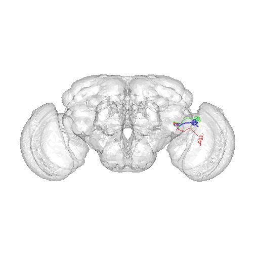

```r
plot3d(vpns[1:3])
# and add brain surface
fcwbsurf()
```

## Cluster cells by morphology

Let's find all the bilateral lobula complex neurons, insisting on at least 500 voxels in each optic lobula complex.

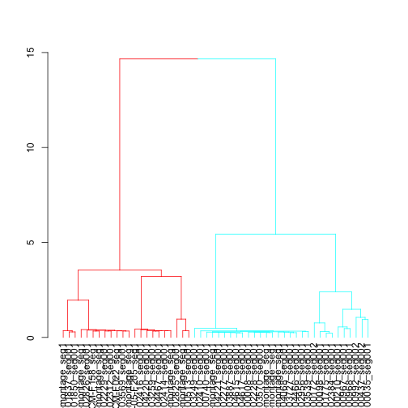

```r
bilateral = subset(vpns, (rLOP + rLOB) > 500 & (lLOP + lLOB) > 500, rval = "names")
hcbilateral <- hclustfc(bilateral)
# two big clusters
library(dendroextras)
plot(colour_clusters(hcbilateral, k = 2))
```

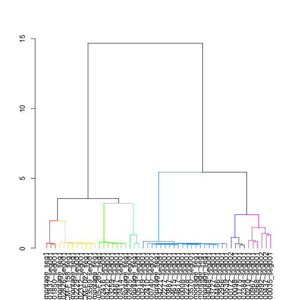

```r
# or 7 finer scale ones
plot(colour_clusters(hcbilateral, k = 7))
```

### Plot 2 major clusters

Now let's look at the two major clusters:

```r
open3d()
```

```
## glX
##   2
```

[figure not shown]

```r
plot3d(hcbilateral, k = 2, db = vpns)
# add lobula
fcwbnpsurf("LO_L", alpha = 0.5)
```

Looks like Lobula vs Medulla (not that much in Lobula Plate)

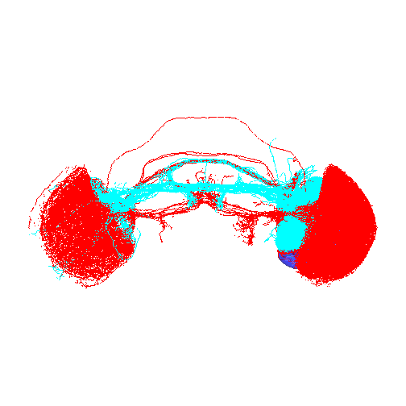

```r
# remove lobula
pop3d()
# ... and add lobula plate
fcwbnpsurf("LOP_L", alpha = 0.5)
```

### Plot 7 finer scale clusters

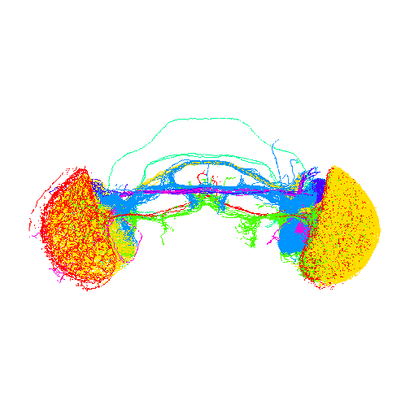

```r
clear3d()
plot3d(hcbilateral, k = 7, db = vpns)
```

## More NBLASTing

How do other neurons compare with 5HT1bMARCM-F000019_seg001? Let's NBLAST it against all the other neurons and look at the distribution of scores.

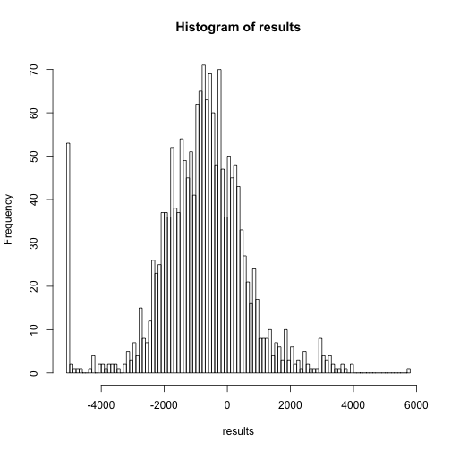

```r
results <- fc_nblast(names(vpns)[1], names(vpns))
hist(results, breaks = 100)
```

The little bump at 5717.3936 is for 5HT1bMARCM-F000019_seg001 itself, which has the highest score possible as there should be no distance between it and itself. Let's plot the next four hits, along with the query neuron in black, to see how similar they are:

```r
open3d()
```

```
## glX
##   3
```

[figure not shown]

```r
plot3d(names(vpns)[1], col = "black")
plot3dfc(names(sort(results, decreasing = TRUE)[2:5]))
```

```r
open3d()
```

```
## glX
##   4
```

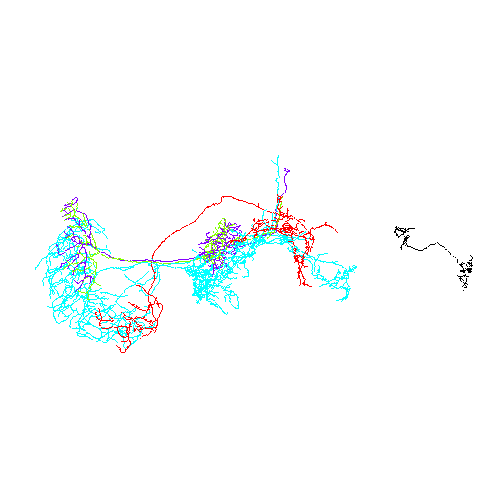

```r
plot3d(names(vpns)[1], col = "black")
plot3dfc(names(sort(results)[1:4]))
```

Definitely different.